# Izravnanje GPS vektora

Milutin Pejović

17 November 2020

## Učitavanje podataka

```r
##################################### Ucitavanje Umka_Bg vektor #####################################################

umka_bg_files <- list.files(here::here("data", "Umka_BG_24h"))

umka.names <- c("header", "UTC_fix", "UTC_date", "latitude", "hemisphere", "longitude", "E/W", "GPS_quality", "n_satellites", "coord_quality", "antenna_altitude", "Altitude_units", "GDOP", "variance_factor", "C11", "C12", "C13", "C22", "C23", "C33")


umka_bg_list <- list()
for(i in 1:length(umka_bg_files)){
  umka_bg_list[[i]] <- read.table(here("data", "Umka_BG_24h", umka_bg_files[i]), sep = ",", na.strings = NA, fill = TRUE, header =  FALSE, col.names = umka.names)
  }

umka_bg_df <- data.frame()
for(i in 1:length(umka_bg_list)){
  umka_bg_df <- rbind(umka_bg_df, umka_bg_list[[i]])
}

#################################### Ucitavanje Umka_Grocka vektor ###################################################

umka_gr_files <- list.files(here::here("data", "Umka_Grocka_24h"))

umka_gr_list <- list()
for(i in 1:length(umka_gr_files)){
  umka_gr_list[[i]] <- read.table(here("data", "Umka_Grocka_24h", umka_gr_files[i]), sep = ",", na.strings = NA, fill = TRUE, header =  FALSE, col.names = umka.names)     # 3. body
}


umka_gr_df <- data.frame()
for(i in 1:length(umka_gr_list)){
  umka_gr_df <- rbind(umka_gr_df, umka_gr_list[[i]])
}

################################### Ucitavanje Umka_Indjija vektor ####################################################

umka_in_files <- list.files(here::here("data", "Umka_Indjija_24h"))

umka_in_list <- list()
for(i in 1:length(umka_in_files)){
  umka_in_list[[i]] <- read.table(here("data", "Umka_Indjija_24h", umka_in_files[i]), sep = ",", na.strings = NA, fill = TRUE, header =  FALSE, col.names = umka.names)     # 3. body
}

umka_in_df <- data.frame()
for(i in 1:length(umka_in_list)){
  umka_in_df <- rbind(umka_in_df, umka_in_list[[i]])
}

###################################################################################################################
```

```r
# Spajanje svih u jedan data.frame
umka.df <- rbind(umka_bg_df, umka_gr_df, umka_in_df)

# Obelezavanje merenja koja imaju fixed i float resenje
# umka.df$GPS_quality <- factor(umka.df$GPS_quality, labels = c("fixed", "float"))

# Kreiranje atributa GPS_vector koji identifikuje pripadnost odredjenom vektoru
umka.df$GPS_vector <- factor(c(rep("Beograd", dim(umka_bg_df)[1]), rep("Grocka", dim(umka_gr_df)[1]), rep("Indjija", dim(umka_in_df)[1])))

# Izbacivanje merenja koja imaju NA vrednosti
umka.df <- umka.df[complete.cases(umka.df), ]

# Konverzija promenljive `n_satellites` u kategorijsku (faktor)
umka.df$n_satellites <- as.factor(umka.df$n_satellites)
```

### Konverzija `UTC_date` u datumski podatak

```r
# UTC_date kolona ima format mmddyy
# umka.df$UTC_date

# Da bi se konvertovala u datum mora se opisati format

# Ali prethodno mora biti konvertovana u tekstualni podatak
# typeof(umka.df$UTC_date)

umka.df$UTC_date <- as.character(umka.df$UTC_date)

# Pojavljuje se drugi problem, neki zapisi imaju 5 karaktera: Jedan za mesece, dva za dane, dva za godine.

# Napraviti logicki vektor identifikuje vrste koje imaju 5 karaktera.
five_char <- nchar(umka.df$UTC_date) == 5

# Iskoristiti tu kolonu u selekciji i konverziji zapisa u 6-to karakterni
# Potrebno je dodati nulu ispred jednocifrenih meseci
# Komanda `paste` je iskorišćena za kreiranje tekstualnog podatka

umka.df$UTC_date[five_char] <- paste(0, umka.df$UTC_date[five_char], sep = "")

# Na kraju konverzija u datum se može uraditi komandom `as.Date()`

umka.df$UTC_date <- as.Date(umka.df$UTC_date, format = "%m%d%y")
```

## Priprema podataka za izravnanje GPS vektora

Cilj ove vezbe je uraditi izravnanje GPS vektora koji se sustiču u tački `Umka` i to u svakoj epohi, tj. za svaki ciklus merenja (u ovom slučaju to je na svakih 24h). Pre svega, treba imati u vidu da su merene veličine u stvari koordinatne razlike izmedju fiksnih tačaka (`Beograd`, `Grocka` i `Indjija`) i tačke `Umka`. Imajući to u vidu, potrebno da definišemo funkcionalni i stohastički model koji opisuje sistem merenih veličina preko nepoznatih parametara (koordinata tačke `Umka`). To podrazumeva kreiranje matrice modela (A matrica - ista za svaku epohu), kreiranje vektora merenih veličina (koordinatnih razlika) i vektora slobodnih članova (l i f - razlikuju se od epohe do epohe), kreiranje stohastičkog modela (Kl - razlikuje se od epohe do epohe). Za tim je potrebno primeniti algoritam MNK izravnanja na svaku epohu i oceniti koordinate. Pri tome, treba imati u vidu kako su podaci organizovani i kako ih pripremiti za primenu algoritma izravnanja.

Imajući u vidu šta je sve potrebno pripremiti, šta je nepromenljivo od epohe do epohe, a šta se menja, logično je pripremiti podatke tako što ćemo proširiti `data.frame` `umka.df` kolonama koje sadrže elemente matrica koje se menjaju od epohe do epohe, a to su:

- Približne vrednosti nepoznatih parametara
- Rezultati merenja koordinatnih razlika
- Približne vrednostima merenih veličina
- Vektor slobodnih članova.

Za ovo su nam potrebni i vrednosti merenih koordinata u svakoj epohi i koordinate fiksnih tačaka (u pravouglom geocentričnom koordinatnom sistemu).

Nakon toga, moguće je primeniti algoritam MNK izravnanja na svaku vrstu `data.frame`-a `umka.df`.

Pre svega, potrebno je sagledati da li je za svaku epohu ispunjen uslov da postoje rezultati merenja tri vektora.

Da bi smo to uradili neophodno je uraditi pripremu podataka koja podrazumeva:

- Promenu zapisa koordinata iz `stepmin,sec`, u decimalni zapis (`step+min/60+sec/3600`)
- Transformaciju koordinata iz ($\phi, \lambda, h$) u $X,Y,Z$ (pravougle geocentrične)
- Pripremiti podatke za kreiranje kovariacione matrice
- Proširiti `data.frame` `umka.df` neophodnim podacima:
- Koordinate stanica Beograd, Grocka i Indjija (Učitati ih iz `excel` fajla)
- Merene koordinatne razlike (razlike koordinatana za svaku epohu)
- Približne koordinate tačke `Umka` za svaku epohu (izračunati kao sredinu koordinata iz tri vektora u svakoj epohi)
- Približne vrednosti merenih koordinatnih razlika
- Vrednosti vektora slobodnih članova

### Transformacija podataka korišćenjem `dplyr` paketa

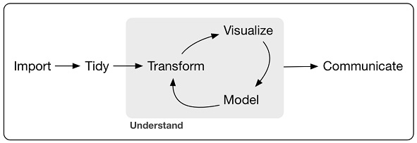